# Análisis personas condenadas años 2013-2019

```r
df_kmeans <-aggregate(datos_condenados_dummies_2013[,c(-32,-33)], by = list(datos_condenados_dummies_2013$Segmentos_kmeans), mean)

df_kmdeoids <- aggregate(datos_condenados_dummies_2013[,c(-31,-33)], by = list(datos_condenados_dummies_2013$Segmentos_kmdeoids), mean)

df_hclust <- aggregate(datos_condenados_dummies_2013[,c(-31,-32)], by = list(datos_condenados_dummies_2013$Segmentos_hclust), mean)


df_kmeans[,c(-1, -31, -32)] <- lapply(df_kmeans[,c(-1, -31, -32)], function(x) x*100)
df_kmdeoids[,c(-1, -31, -32)] <- lapply(df_kmdeoids[,c(-1, -31, -32)], function(x) x*100)
df_hclust[,c(-1, -31, -32)] <- lapply(df_hclust[,c(-1, -31, -32)], function(x) x*100)

df_kmeans
```

```
##   Group.1 ComunidadesAndalucia ComunidadesAragon ComunidadesAsturias
## 1       1             5.263158          5.263158            5.263158
## 2       2             5.263158          5.263158            5.263158
##   ComunidadesBaleares ComunidadesCanarias ComunidadesCantabria
## 1            5.263158            5.263158             5.263158
## 2            5.263158            5.263158             5.263158
##   ComunidadesCastilla_Leon ComunidadesCastilla_Mancha ComunidadesCatalunia
## 1                 5.263158                   5.263158             5.263158
## 2                 5.263158                   5.263158             5.263158
##   ComunidadesCeuta_Melilla ComunidadesExtremadura ComunidadesGalicia
## 1                 10.52632               5.263158           5.263158
## 2                 10.52632               5.263158           5.263158
##   ComunidadesMadrid ComunidadesMurcia ComunidadesNavarra ComunidadesPais_vasco
## 1          5.263158          5.263158           5.263158              5.263158
## 2          5.263158          5.263158           5.263158              5.263158
##   ComunidadesRioja ComunidadesValencia SexoHombres SexoMujeres Edad18_20_anios
## 1         5.263158            5.263158           0         100        11.11111
## 2         5.263158            5.263158         100           0        11.11111
##   Edad21_25_anios Edad26_30_anios Edad31_35_anios Edad36_40_anios
## 1        11.11111        11.11111        11.11111        11.11111
## 2        11.11111        11.11111        11.11111        11.11111
##   Edad41_50_anios Edad51_60_anios Edad61_70_anios Edadmayor_70_anios
## 1        11.11111        11.11111        11.11111           11.11111
## 2        11.11111        11.11111        11.11111           11.11111
##   Numero_Condenados Segmentos_kmeans
## 1          147.2515                1
## 2         1137.9883                2
```

```r
df_kmdeoids
```

```
##   Group.1 ComunidadesAndalucia ComunidadesAragon ComunidadesAsturias
## 1       1             5.263158          5.263158            5.263158
## 2       2             5.263158          5.263158            5.263158
##   ComunidadesBaleares ComunidadesCanarias ComunidadesCantabria
## 1            5.263158            5.263158             5.263158
## 2            5.263158            5.263158             5.263158
##   ComunidadesCastilla_Leon ComunidadesCastilla_Mancha ComunidadesCatalunia
## 1                 5.263158                   5.263158             5.263158
## 2                 5.263158                   5.263158             5.263158
##   ComunidadesCeuta_Melilla ComunidadesExtremadura ComunidadesGalicia
## 1                 10.52632               5.263158           5.263158
## 2                 10.52632               5.263158           5.263158
##   ComunidadesMadrid ComunidadesMurcia ComunidadesNavarra ComunidadesPais_vasco
## 1          5.263158          5.263158           5.263158              5.263158
## 2          5.263158          5.263158           5.263158              5.263158
##   ComunidadesRioja ComunidadesValencia SexoHombres SexoMujeres Edad18_20_anios
## 1         5.263158            5.263158    88.88889    11.11111        11.11111
## 2         5.263158            5.263158    11.11111    88.88889        11.11111
##   Edad21_25_anios Edad26_30_anios Edad31_35_anios Edad36_40_anios
## 1        11.11111        22.22222        11.11111        11.11111
## 2        11.11111         0.00000        11.11111        11.11111
##   Edad41_50_anios Edad51_60_anios Edad61_70_anios Edadmayor_70_anios
## 1        11.11111        11.11111        11.11111            0.00000
## 2        11.11111        11.11111        11.11111           22.22222
##   Numero_Condenados Segmentos_kmdeoids
## 1         1155.9064                  1
## 2          129.3333                  2
```

```r
df_hclust
```

```
##   Group.1 ComunidadesAndalucia ComunidadesAragon ComunidadesAsturias
## 1       1                  100          0.000000            0.000000
## 2       2                    0          5.555556            5.555556
##   ComunidadesBaleares ComunidadesCanarias ComunidadesCantabria
## 1            0.000000            0.000000             0.000000
## 2            5.555556            5.555556             5.555556
##   ComunidadesCastilla_Leon ComunidadesCastilla_Mancha ComunidadesCatalunia
## 1                 0.000000                   0.000000             0.000000
## 2                 5.555556                   5.555556             5.555556
##   ComunidadesCeuta_Melilla ComunidadesExtremadura ComunidadesGalicia
## 1                  0.00000               0.000000           0.000000
## 2                 11.11111               5.555556           5.555556
##   ComunidadesMadrid ComunidadesMurcia ComunidadesNavarra ComunidadesPais_vasco
## 1          0.000000          0.000000           0.000000              0.000000
## 2          5.555556          5.555556           5.555556              5.555556
##   ComunidadesRioja ComunidadesValencia SexoHombres SexoMujeres Edad18_20_anios
## 1         0.000000            0.000000          50          50        11.11111
## 2         5.555556            5.555556          50          50        11.11111
##   Edad21_25_anios Edad26_30_anios Edad31_35_anios Edad36_40_anios
## 1        11.11111        11.11111        11.11111        11.11111
## 2        11.11111        11.11111        11.11111        11.11111
##   Edad41_50_anios Edad51_60_anios Edad61_70_anios Edadmayor_70_anios
## 1        11.11111        11.11111        11.11111           11.11111
## 2        11.11111        11.11111        11.11111           11.11111
##   Numero_Condenados Segmentos_hclust
## 1         2446.2778                1
## 2          542.4167                2
```

## 5.4 Automatización

Se realiza el mismo proceso que se ha hecho con los datos de entrenamiento para el año 2013, pero esta vez con los datos de todos los años.

```r
NUM_CLUSTERS=2
set.seed(1200)
years=c(2013:2019)
kmeans_list=list()
kmedoids_list=list()
hclust_list=list()
for (i in 1:length(years)){
  sprintf("PROCESANDO: %s",years[i])
  datos_condenados_dummies_anio<- subset(datos_condenados_dummies,Anio==years[i])
  #No necesito la variable año
  datos_condenados_dummies_anio$Anio=NULL
  #Normalizo los datos
  datos_condenados_dummies_anio_nor=scale(datos_condenados_dummies_anio)
  #Hay columnas con datos a 0, al normalizar salen NA. Lo vuelvo a poner a 0
  datos_condenados_dummies_anio_nor[is.na(datos_condenados_dummies_anio_nor)] <- 0

  #KMEANS
  Modelo_kmeans=kmeans(datos_condenados_dummies_anio_nor,NUM_CLUSTERS)
  datos_condenados_dummies_anio$Segmentos_kmeans=Modelo_kmeans$cluster


  #KMEDOIDS
  Modelo_kmedoids=pam(datos_condenados_dummies_anio_nor,NUM_CLUSTERS)
  datos_condenados_dummies_anio$Segmentos_kmdeoids=Modelo_kmedoids$cluster

  #HCLUST
  distancia <- dist(datos_condenados_dummies_anio_nor, method = "euclidean")
  Modelo_hclust<- hclust(distancia, method = "complete")
  datos_condenados_dummies_anio$Segmentos_hclust = cutree(Modelo_hclust, k = NUM_CLUSTERS)

  #Incluyo columna con el año
  datos_condenados_dummies_anio$Anio=years[i]

  #tamaños de los clusters
  table(datos_condenados_dummies_anio$Segmentos_kmeans)
  table(datos_condenados_dummies_anio$Segmentos_kmdeoids)
  table(datos_condenados_dummies_anio$Segmentos_hclust)

  #guardo en la lista por numero de cluster cada tipo

  kmeans_list[[i]]=aggregate(datos_condenados_dummies_anio[,c(-32,-33)],
                                by =list(datos_condenados_dummies_anio$Segmentos_kmeans), mean)

  kmeans_list[[i]][,c(-1, -31, -32, -33)] <- lapply(kmeans_list[[i]][,c(-1, -31, -32, -33)], function(x) x*100)

  kmedoids_list[[i]]=aggregate(datos_condenados_dummies_anio[,c(-31,-33)],
                                  by = list(datos_condenados_dummies_anio$Segmentos_kmdeoids), mean)

  kmedoids_list[[i]][,c(-1, -31, -32, -33)] <- lapply(kmedoids_list[[i]][,c(-1, -31, -32, -33)], function(x) x*100)

  hclust_list[[i]]=aggregate(datos_condenados_dummies_anio[,c(-31,-32)],
                        by = list(datos_condenados_dummies_anio$Segmentos_hclust), mean)

  hclust_list[[i]][,c(-1, -31, -32, -33)] <- lapply(hclust_list[[i]][,c(-1, -31, -32, -33)], function(x) x*100)

}


print(kmeans_list)
```

```
## [[1]]
##   Group.1 ComunidadesAndalucia ComunidadesAragon ComunidadesAsturias
## 1       1             5.263158          5.263158            5.263158
## 2       2             5.263158          5.263158            5.263158
##   ComunidadesBaleares ComunidadesCanarias ComunidadesCantabria
## 1            5.263158            5.263158             5.263158
## 2            5.263158            5.263158             5.263158
##   ComunidadesCastilla_Leon ComunidadesCastilla_Mancha ComunidadesCatalunia
## 1                 5.263158                   5.263158             5.263158
## 2                 5.263158                   5.263158             5.263158
##   ComunidadesCeuta_Melilla ComunidadesExtremadura ComunidadesGalicia
## 1                 10.52632               5.263158           5.263158
## 2                 10.52632               5.263158           5.263158
##   ComunidadesMadrid ComunidadesMurcia ComunidadesNavarra ComunidadesPais_vasco
## 1          5.263158          5.263158           5.263158              5.263158
## 2          5.263158          5.263158           5.263158              5.263158
##   ComunidadesRioja ComunidadesValencia SexoHombres SexoMujeres Edad18_20_anios
## 1         5.263158            5.263158           0         100        11.11111
## 2         5.263158            5.263158         100           0        11.11111
##   Edad21_25_anios Edad26_30_anios Edad31_35_anios Edad36_40_anios
## 1        11.11111        11.11111        11.11111        11.11111
## 2        11.11111        11.11111        11.11111        11.11111
##   Edad41_50_anios Edad51_60_anios Edad61_70_anios Edadmayor_70_anios
## 1        11.11111        11.11111        11.11111           11.11111
## 2        11.11111        11.11111        11.11111           11.11111
##   Numero_Condenados Segmentos_kmeans Anio
## 1          147.2515                1 2013
## 2         1137.9883                2 2013
##
## [[2]]
##   Group.1 ComunidadesAndalucia ComunidadesAragon ComunidadesAsturias
## 1       1             5.555556          5.555556            5.555556
## 2       2             3.703704          3.703704            3.703704
##   ComunidadesBaleares ComunidadesCanarias ComunidadesCantabria
## 1            5.555556            5.555556             5.555556
## 2            3.703704            3.703704             3.703704
##   ComunidadesCastilla_Leon ComunidadesCastilla_Mancha ComunidadesCatalunia
## 1                 5.555556                   5.555556             5.555556
## 2                 3.703704                   3.703704             3.703704
##   ComunidadesCeuta_Melilla ComunidadesExtremadura ComunidadesGalicia
```

[output cut: 147 more lines]

```
##   ComunidadesMadrid ComunidadesMurcia ComunidadesNavarra ComunidadesPais_vasco
## 1          5.263158          5.263158           5.263158              5.263158
## 2          5.263158          5.263158           5.263158              5.263158
##   ComunidadesRioja ComunidadesValencia SexoHombres SexoMujeres Edad18_20_anios
## 1         5.263158            5.263158           0         100        11.11111
## 2         5.263158            5.263158         100           0        11.11111
##   Edad21_25_anios Edad26_30_anios Edad31_35_anios Edad36_40_anios
## 1        11.11111        11.11111        11.11111        11.11111
## 2        11.11111        11.11111        11.11111        11.11111
##   Edad41_50_anios Edad51_60_anios Edad61_70_anios Edadmayor_70_anios
## 1        11.11111        11.11111        11.11111           11.11111
## 2        11.11111        11.11111        11.11111           11.11111
##   Numero_Condenados Segmentos_kmeans Anio
## 1          346.2515                1 2019
## 2         1331.7076                2 2019
```

```r
print(kmedoids_list)
```

```
## [[1]]
##   Group.1 ComunidadesAndalucia ComunidadesAragon ComunidadesAsturias
## 1       1             5.263158          5.263158            5.263158
## 2       2             5.263158          5.263158            5.263158
##   ComunidadesBaleares ComunidadesCanarias ComunidadesCantabria
## 1            5.263158            5.263158             5.263158
## 2            5.263158            5.263158             5.263158
##   ComunidadesCastilla_Leon ComunidadesCastilla_Mancha ComunidadesCatalunia
## 1                 5.263158                   5.263158             5.263158
## 2                 5.263158                   5.263158             5.263158
##   ComunidadesCeuta_Melilla ComunidadesExtremadura ComunidadesGalicia
## 1                 10.52632               5.263158           5.263158
## 2                 10.52632               5.263158           5.263158
##   ComunidadesMadrid ComunidadesMurcia ComunidadesNavarra ComunidadesPais_vasco
## 1          5.263158          5.263158           5.263158              5.263158
## 2          5.263158          5.263158           5.263158              5.263158
##   ComunidadesRioja ComunidadesValencia SexoHombres SexoMujeres Edad18_20_anios
## 1         5.263158            5.263158    88.88889    11.11111        11.11111
## 2         5.263158            5.263158    11.11111    88.88889        11.11111
##   Edad21_25_anios Edad26_30_anios Edad31_35_anios Edad36_40_anios
## 1        11.11111        22.22222        11.11111        11.11111
## 2        11.11111         0.00000        11.11111        11.11111
##   Edad41_50_anios Edad51_60_anios Edad61_70_anios Edadmayor_70_anios
## 1        11.11111        11.11111        11.11111            0.00000
## 2        11.11111        11.11111        11.11111           22.22222
##   Numero_Condenados Segmentos_kmdeoids Anio
## 1         1155.9064                  1 2013
## 2          129.3333                  2 2013
##
## [[2]]
##   Group.1 ComunidadesAndalucia ComunidadesAragon ComunidadesAsturias
## 1       1             5.263158          5.263158            5.263158
## 2       2             5.263158          5.263158            5.263158
##   ComunidadesBaleares ComunidadesCanarias ComunidadesCantabria
## 1            5.263158            5.263158             5.263158
## 2            5.263158            5.263158             5.263158
##   ComunidadesCastilla_Leon ComunidadesCastilla_Mancha ComunidadesCatalunia
## 1                 5.263158                   5.263158             5.263158
## 2                 5.263158                   5.263158             5.263158
##   ComunidadesCeuta_Melilla ComunidadesExtremadura ComunidadesGalicia
```

[output cut: 147 more lines]

```
##   ComunidadesMadrid ComunidadesMurcia ComunidadesNavarra ComunidadesPais_vasco
## 1          5.263158          5.263158           5.263158              5.263158
## 2          5.263158          5.263158           5.263158              5.263158
##   ComunidadesRioja ComunidadesValencia SexoHombres SexoMujeres Edad18_20_anios
## 1         5.263158            5.263158    88.88889    11.11111        11.11111
## 2         5.263158            5.263158    11.11111    88.88889        11.11111
##   Edad21_25_anios Edad26_30_anios Edad31_35_anios Edad36_40_anios
## 1        22.22222        11.11111        11.11111        11.11111
## 2         0.00000        11.11111        11.11111        11.11111
##   Edad41_50_anios Edad51_60_anios Edad61_70_anios Edadmayor_70_anios
## 1        11.11111        11.11111        11.11111            0.00000
## 2        11.11111        11.11111        11.11111           22.22222
##   Numero_Condenados Segmentos_kmdeoids Anio
## 1         1365.9649                  1 2019
## 2          311.9942                  2 2019
```

```r
print(hclust_list)
```

```
## [[1]]
##   Group.1 ComunidadesAndalucia ComunidadesAragon ComunidadesAsturias
## 1       1                  100          0.000000            0.000000
## 2       2                    0          5.555556            5.555556
##   ComunidadesBaleares ComunidadesCanarias ComunidadesCantabria
## 1            0.000000            0.000000             0.000000
## 2            5.555556            5.555556             5.555556
##   ComunidadesCastilla_Leon ComunidadesCastilla_Mancha ComunidadesCatalunia
## 1                 0.000000                   0.000000             0.000000
## 2                 5.555556                   5.555556             5.555556
##   ComunidadesCeuta_Melilla ComunidadesExtremadura ComunidadesGalicia
## 1                  0.00000               0.000000           0.000000
## 2                 11.11111               5.555556           5.555556
##   ComunidadesMadrid ComunidadesMurcia ComunidadesNavarra ComunidadesPais_vasco
## 1          0.000000          0.000000           0.000000              0.000000
## 2          5.555556          5.555556           5.555556              5.555556
##   ComunidadesRioja ComunidadesValencia SexoHombres SexoMujeres Edad18_20_anios
## 1         0.000000            0.000000          50          50        11.11111
## 2         5.555556            5.555556          50          50        11.11111
##   Edad21_25_anios Edad26_30_anios Edad31_35_anios Edad36_40_anios
## 1        11.11111        11.11111        11.11111        11.11111
## 2        11.11111        11.11111        11.11111        11.11111
##   Edad41_50_anios Edad51_60_anios Edad61_70_anios Edadmayor_70_anios
## 1        11.11111        11.11111        11.11111           11.11111
## 2        11.11111        11.11111        11.11111           11.11111
##   Numero_Condenados Segmentos_hclust Anio
## 1         2446.2778                1 2013
## 2          542.4167                2 2013
##
## [[2]]
##   Group.1 ComunidadesAndalucia ComunidadesAragon ComunidadesAsturias
## 1       1                  100          0.000000            0.000000
## 2       2                    0          5.555556            5.555556
##   ComunidadesBaleares ComunidadesCanarias ComunidadesCantabria
## 1            0.000000            0.000000             0.000000
## 2            5.555556            5.555556             5.555556
##   ComunidadesCastilla_Leon ComunidadesCastilla_Mancha ComunidadesCatalunia
## 1                 0.000000                   0.000000             0.000000
## 2                 5.555556                   5.555556             5.555556
##   ComunidadesCeuta_Melilla ComunidadesExtremadura ComunidadesGalicia
```

[output cut: 147 more lines]

```
##   ComunidadesMadrid ComunidadesMurcia ComunidadesNavarra ComunidadesPais_vasco
## 1          0.000000          0.000000           0.000000              0.000000
## 2          5.555556          5.555556           5.555556              5.555556
##   ComunidadesRioja ComunidadesValencia SexoHombres SexoMujeres Edad18_20_anios
## 1         0.000000            0.000000          50          50        11.11111
## 2         5.555556            5.555556          50          50        11.11111
##   Edad21_25_anios Edad26_30_anios Edad31_35_anios Edad36_40_anios
## 1        11.11111        11.11111        11.11111        11.11111
## 2        11.11111        11.11111        11.11111        11.11111
##   Edad41_50_anios Edad51_60_anios Edad61_70_anios Edadmayor_70_anios
## 1        11.11111        11.11111        11.11111           11.11111
## 2        11.11111        11.11111        11.11111           11.11111
##   Numero_Condenados Segmentos_hclust Anio
## 1         3047.1111                1 2019
## 2          716.3056                2 2019
```

## 5.5 Validación KMEANS

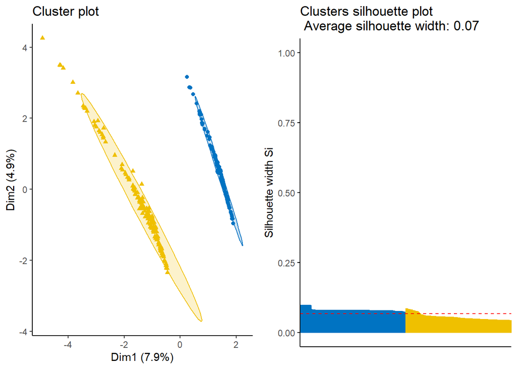

```r
km_clusters <- eclust(x = datos_condenados_dummies_2013_nor, FUNcluster = "kmeans", k = 2, seed = 123,
                      hc_metric = "euclidean", nstart = 50, graph = FALSE)
p1 <- fviz_cluster(object = km_clusters, geom = "point", ellipse.type  = "norm",
                   palette = "jco") +
      theme_classic() + theme(legend.position = "none")

p2 <- fviz_silhouette(sil.obj = km_clusters, print.summary = FALSE,
                      palette = "jco", ggtheme = theme_classic()) +
      theme(legend.position = "none")

ggarrange(p1, p2)
```

## 5.6 Validación KMEDOIDS

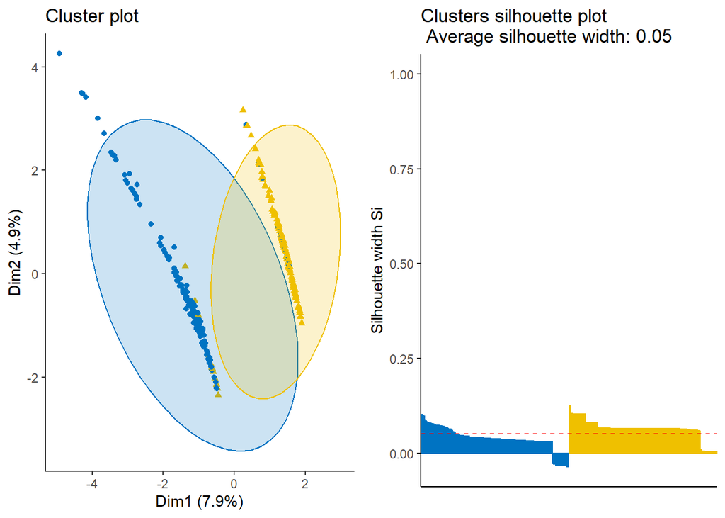

```r
km_clusters <- eclust(x = datos_condenados_dummies_2013_nor, FUNcluster = "pam", k = 2, seed = 123,
                      hc_metric = "euclidean", graph = FALSE)
p1 <- fviz_cluster(object = km_clusters, geom = "point", ellipse.type  = "norm",
                   palette = "jco") +
      theme_classic() + theme(legend.position = "none")

p2 <- fviz_silhouette(sil.obj = km_clusters, print.summary = FALSE,
                      palette = "jco", ggtheme = theme_classic()) +
      theme(legend.position = "none")

ggarrange(p1, p2)
```

## 5.7 Validación HCLUST

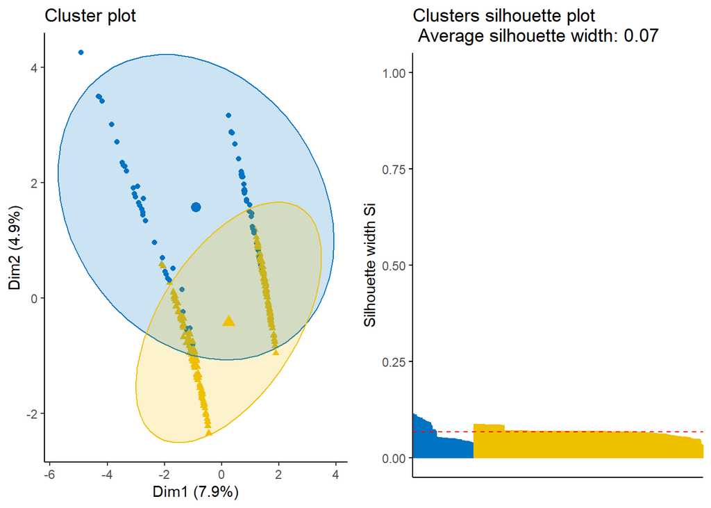

```r
km_clusters <- eclust(x = datos_condenados_dummies_2013_nor, FUNcluster = "hclust", k = 2, seed = 123,
                      hc_metric = "euclidean", nstart = 50, graph = FALSE)
p1 <- fviz_cluster(object = km_clusters, geom = "point", ellipse.type  = "norm",
                   palette = "jco") +
      theme_classic() + theme(legend.position = "none")

p2 <- fviz_silhouette(sil.obj = km_clusters, print.summary = FALSE,
                      palette = "jco", ggtheme = theme_classic()) +
      theme(legend.position = "none")

ggarrange(p1, p2)
```

## 5.8 CONCLUSIÓN

El método Keams ha resultado ser el más fiable de los tres para poder definir los distintos perfiles de los condenados de España, ya que según se ve en el gráfico agrupa correctamente todos datos del mismo grupo. En cambio, tanto en el el Kmedoids como en el HClust no realiza una separación tan clara de los grupos, incluyendo en algunas ocasiones datos correspondientes al grupo contrario.

[output not shown]